# Topic 6: Support Vector Machines

Maximum Margin Classifiers and the Kernel Trick

MS in Statistics for Data Science

UC3M, 2026

# 1 Introduction

Support Vector Machines (SVMs) are powerful classifiers that find the optimal decision boundary by maximizing the margin between classes. Recall from the theory seen in the slides that we can explain how they are built with the following steps:

1. **Maximal Margin Classifiers**: finding the widest separating hyperplane
2. **Support Vector Classifiers**: Handling non-separable data with soft margins
3. **Support Vector Machines**: Using kernels to handle non-linear boundaries

We will see toy examples with simulated data for each of them. Afterwards, we will see a case study with airline delays and finally an example of multiclass SVM classification.

```r
# Core packages
library(tidyverse)    # Data manipulation and visualization
library(e1071)        # SVM implementation
library(caret)        # Model training and evaluation
library(kernlab)      # Alternative SVM implementation
library(pROC)         # ROC curves and AUC

# Visualization
library(ggplot2)
library(patchwork)
library(viridis)

# Set seed for reproducibility
set.seed(42)
```

# 2 Maximal Margin Classifier (Hard margin)

This chunk simulates a simple 2D dataset where the two classes can be perfectly separated by a linear boundary.

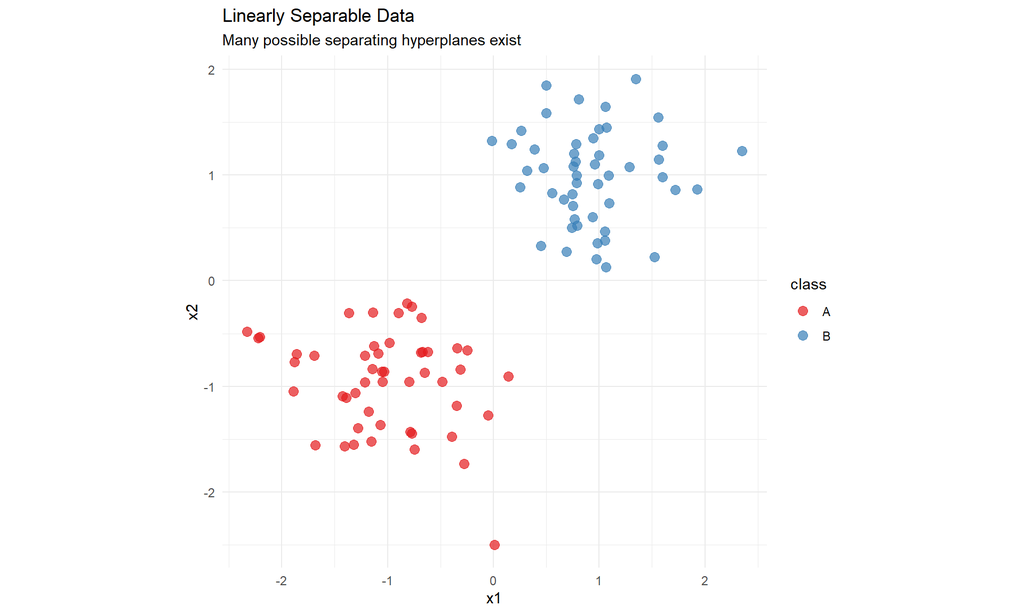

```r
# Generate linearly separable data
set.seed(42)
n <- 100

# Class 1: bottom-left cluster
class1 <- data.frame(
  x1 = rnorm(n/2, mean = -1, sd = 0.5),
  x2 = rnorm(n/2, mean = -1, sd = 0.5),
  class = "A"
)

# Class 2: top-right cluster
class2 <- data.frame(
  x1 = rnorm(n/2, mean = 1, sd = 0.5),
  x2 = rnorm(n/2, mean = 1, sd = 0.5),
  class = "B"
)

separable_data <- rbind(class1, class2)
separable_data$class <- factor(separable_data$class)

# Visualize
ggplot(separable_data, aes(x = x1, y = x2, color = class)) +
  geom_point(size = 3, alpha = 0.7) +
  labs(title = "Linearly Separable Data",
       subtitle = "Many possible separating hyperplanes exist") +
  theme_minimal() +
  scale_color_brewer(palette = "Set1") +
  coord_fixed()
```

Now we fit a linear SVM to the simulated data and inspect which observations become support vectors.

> Note that we are using the SVM function, but by choosing the linear kernel it is a support vector classifier, and by setting a “high” cost its equivalent to having a hard margin. Here the parameter cost models in an opposite way the C parameter from our slides, where C=0 was a hard constraint, here a high cost value also creates a hard margin (in our data case 10 is large enough)

```r
# Fit SVM with linear kernel
svm_linear <- svm(class ~ x1 + x2, data = separable_data,
                  kernel = "linear",
                  cost = 10,
                  scale = FALSE)

# Model summary
summary(svm_linear)
```

```
##
## Call:
## svm(formula = class ~ x1 + x2, data = separable_data, kernel = "linear",
##     cost = 10, scale = FALSE)
##
##
## Parameters:
##    SVM-Type:  C-classification
##  SVM-Kernel:  linear
##        cost:  10
##
## Number of Support Vectors:  3
##
##  ( 2 1 )
##
##
## Number of Classes:  2
##
## Levels:
##  A B
```

```r
# Identify support vectors
cat("\nNumber of support vectors:", length(svm_linear$index), "\n")
```

```
##
## Number of support vectors: 3
```

```r
cat("Support vector indices:", svm_linear$index, "\n")
```

```
## Support vector indices: 12 31 86
```

Next we visualize the decision regions, separating hyperplane, margins, and support vectors.

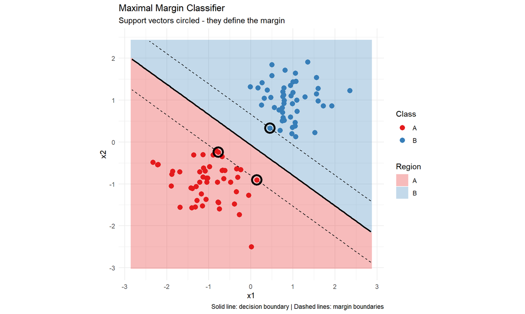

```r
# Create a grid for plotting
x1_range <- seq(min(separable_data$x1) - 0.5, max(separable_data$x1) + 0.5, length = 100)
x2_range <- seq(min(separable_data$x2) - 0.5, max(separable_data$x2) + 0.5, length = 100)
grid <- expand.grid(x1 = x1_range, x2 = x2_range)

# Predict on grid
grid$pred <- predict(svm_linear, grid)
decision_vals <- attr(predict(svm_linear, grid, decision.values = TRUE), "decision.values")
grid$decision <- as.numeric(decision_vals)

# Plot
ggplot() +
  geom_tile(data = grid, aes(x = x1, y = x2, fill = pred), alpha = 0.3) +
  geom_contour(data = grid, aes(x = x1, y = x2, z = decision),
               breaks = c(-1, 1), color = "black", linewidth = 0.5, linetype = "dashed") +
  geom_contour(data = grid, aes(x = x1, y = x2, z = decision),
               breaks = 0, color = "black", linewidth = 1) +
  geom_point(data = separable_data, aes(x = x1, y = x2, color = class), size = 3) +
  geom_point(data = separable_data[svm_linear$index, ],
             aes(x = x1, y = x2), shape = 1, size = 5, stroke = 2) +
  labs(title = "Maximal Margin Classifier",
       subtitle = "Support vectors circled - they define the margin",
       caption = "Solid line: decision boundary | Dashed lines: margin boundaries") +
  theme_minimal() +
  scale_fill_brewer(palette = "Set1", name = "Region") +
  scale_color_brewer(palette = "Set1", name = "Class") +
  coord_fixed()
```

# 3 Support Vector Classifier (Soft Margin)

In this example we will use a soft margin classifier in data that is almost separable.

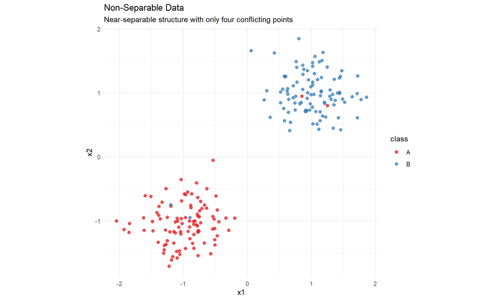

```r
# Separable data with a 4 "wrong" points
set.seed(42)
n_core <- 196

# Core clusters
class1_core <- data.frame(
  x1 = rnorm(n_core/2, mean = -1.0, sd = 0.35),
  x2 = rnorm(n_core/2, mean = -1.0, sd = 0.35),
  class = "A"
)

class2_core <- data.frame(
  x1 = rnorm(n_core/2, mean = 1.0, sd = 0.35),
  x2 = rnorm(n_core/2, mean = 1.0, sd = 0.35),
  class = "B"
)

# Two mislabeled points from class A inside the class B region
class1_conflict <- data.frame(
  x1 = c(0.85, 1.25),
  x2 = c(0.95, 0.80),
  class = "A"
)

# Two mislabeled points from class B inside the class A region
class2_conflict <- data.frame(
  x1 = c(-0.90, -1.20),
  x2 = c(-0.95, -0.75),
  class = "B"
)

overlap_data <- rbind(class1_core, class2_core, class1_conflict, class2_conflict)
overlap_data$class <- factor(overlap_data$class)

# Visualize
ggplot(overlap_data, aes(x = x1, y = x2, color = class)) +
  geom_point(size = 2, alpha = 0.75) +
  labs(title = "Non-Separable Data",
       subtitle = "Near-separable structure with only four conflicting points") +
  theme_minimal() +
  scale_color_brewer(palette = "Set1") +
  coord_fixed()
```

Here we compare different values of the cost parameter C and how they change the boundary complexity. The cost parameter controls the penalty for misclassification (remember that in our slides $C$ was the “busget”, so goes in the opposite direction):

- **Low cost**: Wide margin, more violations (potential underfitting)
- **High cost**: Narrow margin, fewer violations (potential overfitting)

```r
# Fit SVMs with different C values
svm_low_cost <- svm(class ~ x1 + x2, data = overlap_data, kernel = "linear", cost = 0.01, scale = FALSE)
svm_high_cost <- svm(class ~ x1 + x2, data = overlap_data, kernel = "linear", cost = 10, scale = FALSE)

# Margin width for linear SVM:
get_margin_width <- function(model) {
  w <- drop(t(model$coefs) %*% model$SV)
  2 / sqrt(sum(w^2))
}

margin_low <- get_margin_width(svm_low_cost)
margin_high <- get_margin_width(svm_high_cost)

# Function to create decision boundary plot
plot_svm <- function(model, data, title, show_margins = FALSE, margin_width = NULL) {
  x1_range <- seq(min(data$x1) - 0.5, max(data$x1) + 0.5, length = 100)
  x2_range <- seq(min(data$x2) - 0.5, max(data$x2) + 0.5, length = 100)
  grid <- expand.grid(x1 = x1_range, x2 = x2_range)
  grid$pred <- predict(model, grid)
  decision_vals <- attr(predict(model, grid, decision.values = TRUE), "decision.values")
  grid$decision <- as.numeric(decision_vals)

  subtitle_txt <- paste("Support vectors:", length(model$index))
  if (!is.null(margin_width)) {
    subtitle_txt <- paste0(subtitle_txt, " | Margin width: ", round(margin_width, 2))
  }

  p <- ggplot() +
    geom_tile(data = grid, aes(x = x1, y = x2, fill = pred), alpha = 0.3) +
    geom_point(data = data, aes(x = x1, y = x2, color = class), size = 2) +
    geom_point(data = data[model$index, ], aes(x = x1, y = x2),
               shape = 1, size = 4, stroke = 1.5) +
    labs(title = title, subtitle = subtitle_txt) +
    theme_minimal(base_size = 12) +
    scale_fill_brewer(palette = "Set1") +
    scale_color_brewer(palette = "Set1") +
    coord_fixed() +
    theme(legend.position = "none")

  if (show_margins) {
    p <- p +
      geom_contour(data = grid, aes(x = x1, y = x2, z = decision),
                   breaks = c(-1, 1), color = "black", linewidth = 0.5, linetype = "dashed") +
      geom_contour(data = grid, aes(x = x1, y = x2, z = decision),
                   breaks = 0, color = "black", linewidth = 1)
  }

  p
}

# Compare
cost_summary <- tibble(
  Cost = c(0.01, 100),
  SupportVectors = c(length(svm_low_cost$index), length(svm_high_cost$index)),
  MarginWidth = round(c(margin_low, margin_high), 3)
)
cost_summary
```

[output not shown]

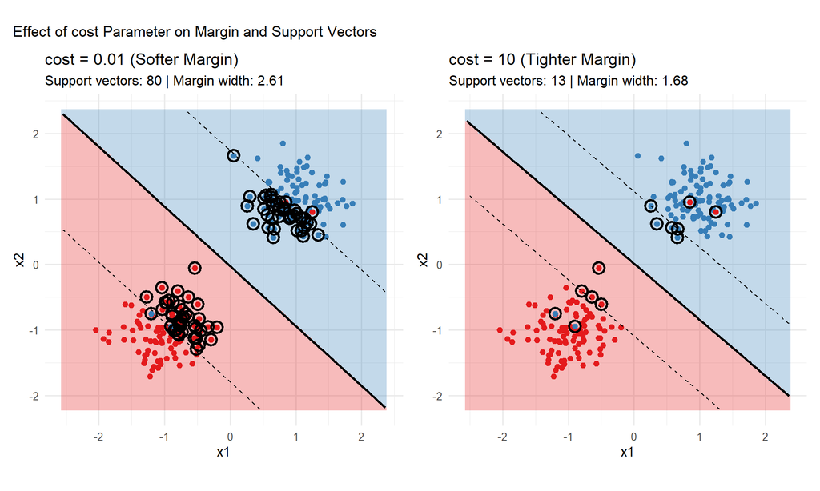

```r
p1 <- plot_svm(svm_low_cost, overlap_data, "cost = 0.01 (Softer Margin)",
               show_margins = TRUE, margin_width = margin_low)
p2 <- plot_svm(svm_high_cost, overlap_data, "cost = 10 (Tighter Margin)",
               show_margins = TRUE, margin_width = margin_high)

(p1 | p2) + plot_annotation(title = "Effect of cost Parameter on Margin and Support Vectors")
```

# 4 Kernel SVM (Non-Linear Boundaries)

Now we will see an example with non linear data:

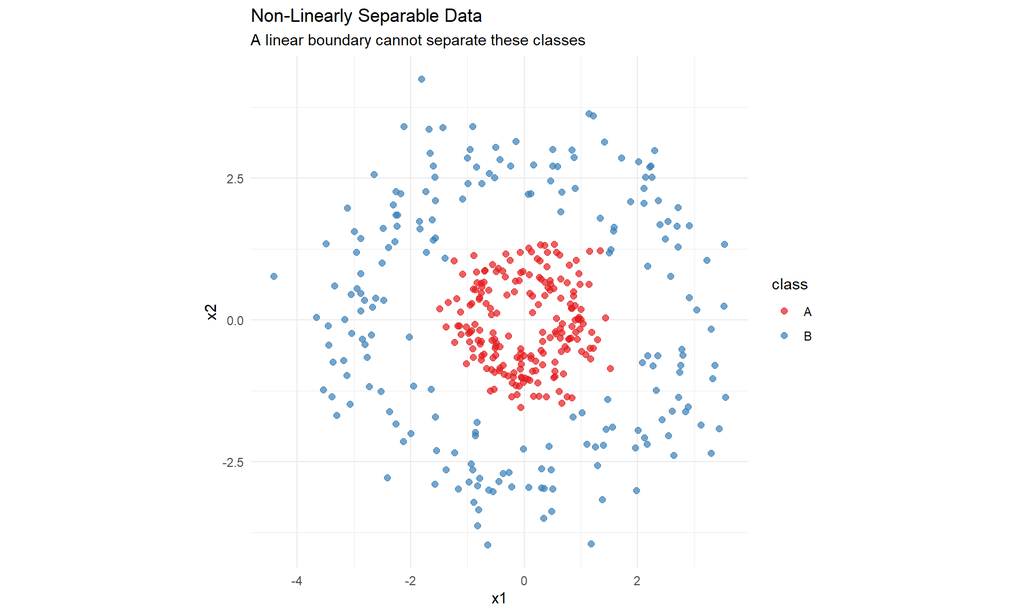

```r
# Generate circular data
set.seed(42)
n <- 400

# Inner circle (Class A)
theta1 <- runif(n/2, 0, 2*pi)
r1 <- rnorm(n/2, mean = 1, sd = 0.3)
inner <- data.frame(
  x1 = r1 * cos(theta1),
  x2 = r1 * sin(theta1),
  class = "A"
)

# Outer ring (Class B)
theta2 <- runif(n/2, 0, 2*pi)
r2 <- rnorm(n/2, mean = 3, sd = 0.5)
outer <- data.frame(
  x1 = r2 * cos(theta2),
  x2 = r2 * sin(theta2),
  class = "B"
)

circle_data <- rbind(inner, outer)
circle_data$class <- factor(circle_data$class)

# Visualize
ggplot(circle_data, aes(x = x1, y = x2, color = class)) +
  geom_point(size = 2, alpha = 0.7) +
  labs(title = "Non-Linearly Separable Data",
       subtitle = "A linear boundary cannot separate these classes") +
  theme_minimal() +
  scale_color_brewer(palette = "Set1") +
  coord_fixed()
```

We first fit a linear SVM on the circular data to show the limitations of a linear decision boundary.

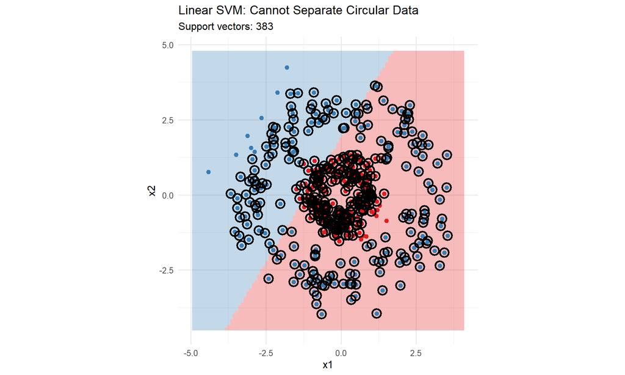

```r
# Try linear SVM
svm_linear_fail <- svm(class ~ x1 + x2, data = circle_data, kernel = "linear", cost = 1)

# Plot
plot_svm(svm_linear_fail, circle_data, "Linear SVM: Cannot Separate Circular Data")
```

Next we fit an SVM with an RBF kernel, which handles non-linear structure through the kernel trick. The RBF kernel maps data to a higher-dimensional space where it becomes linearly separable.

$$K(x, x') = \exp\left(-\gamma \|x -
x'\|^2\right)$$

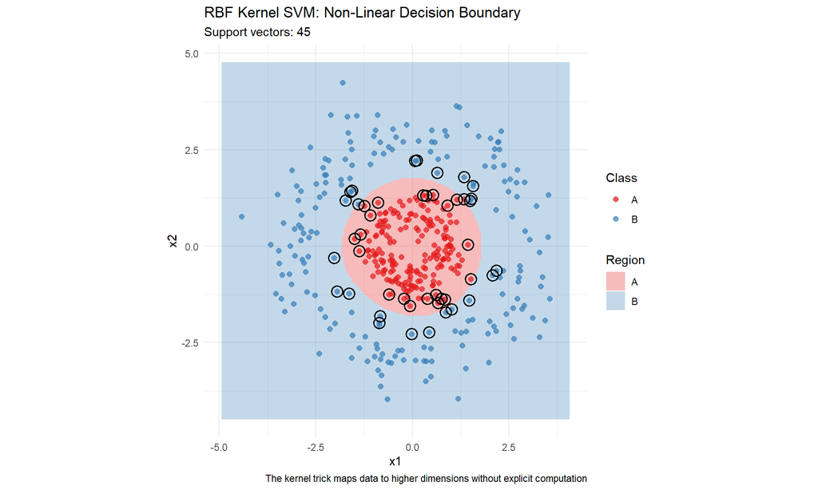

```r
# Fit SVM with RBF kernel
svm_rbf <- svm(class ~ x1 + x2, data = circle_data,
               kernel = "radial",
               gamma = 0.5, # remember that you can tune the gamma parameters
               cost = 1)

# Create detailed decision boundary plot
x1_range <- seq(min(circle_data$x1) - 0.5, max(circle_data$x1) + 0.5, length = 200)
x2_range <- seq(min(circle_data$x2) - 0.5, max(circle_data$x2) + 0.5, length = 200)
grid <- expand.grid(x1 = x1_range, x2 = x2_range)
grid$pred <- predict(svm_rbf, grid)

ggplot() +
  geom_tile(data = grid, aes(x = x1, y = x2, fill = pred), alpha = 0.3) +
  geom_point(data = circle_data, aes(x = x1, y = x2, color = class), size = 2, alpha = 0.7) +
  geom_point(data = circle_data[svm_rbf$index, ], aes(x = x1, y = x2),
             shape = 1, size = 4, stroke = 1) +
  labs(title = "RBF Kernel SVM: Non-Linear Decision Boundary",
       subtitle = paste("Support vectors:", length(svm_rbf$index)),
       caption = "The kernel trick maps data to higher dimensions without explicit computation") +
  theme_minimal() +
  scale_fill_brewer(palette = "Set1", name = "Region") +
  scale_color_brewer(palette = "Set1", name = "Class") +
  coord_fixed()
```

We can test a higher gamma now. In the selected support vectors we can see how with this radial kernel we not only get points in the boundary but also the more isolated points that are also too far from the other class. However, in the kernel generated space this is indeed linear.

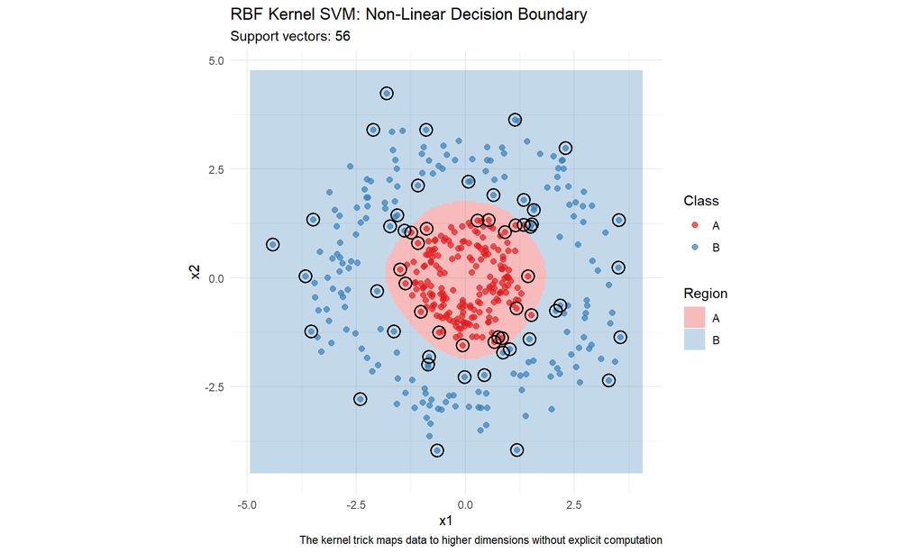

```r
# Fit SVM with RBF kernel now with higher gamma
svm_rbf <- svm(class ~ x1 + x2, data = circle_data,
               kernel = "radial",
               gamma = 2,
               cost = 1)

# Create detailed decision boundary plot
x1_range <- seq(min(circle_data$x1) - 0.5, max(circle_data$x1) + 0.5, length = 200)
x2_range <- seq(min(circle_data$x2) - 0.5, max(circle_data$x2) + 0.5, length = 200)
grid <- expand.grid(x1 = x1_range, x2 = x2_range)
grid$pred <- predict(svm_rbf, grid)

ggplot() +
  geom_tile(data = grid, aes(x = x1, y = x2, fill = pred), alpha = 0.3) +
  geom_point(data = circle_data, aes(x = x1, y = x2, color = class), size = 2, alpha = 0.7) +
  geom_point(data = circle_data[svm_rbf$index, ], aes(x = x1, y = x2),
             shape = 1, size = 4, stroke = 1) +
  labs(title = "RBF Kernel SVM: Non-Linear Decision Boundary",
       subtitle = paste("Support vectors:", length(svm_rbf$index)),
       caption = "The kernel trick maps data to higher dimensions without explicit computation") +
  theme_minimal() +
  scale_fill_brewer(palette = "Set1", name = "Region") +
  scale_color_brewer(palette = "Set1", name = "Class") +
  coord_fixed()
```

We can test with the same non linear data a polynomial kernel

$$K(x, x') = (1 + x^T
x')^d$$

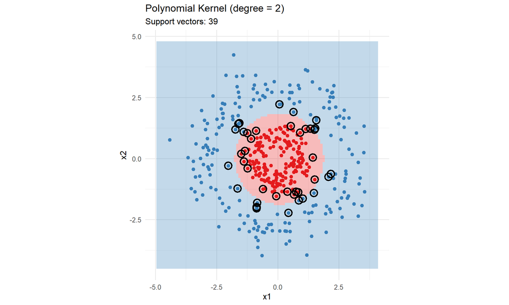

```r
# Fit polynomial SVM (degree 2)
svm_poly <- svm(class ~ x1 + x2, data = circle_data,
                kernel = "polynomial",
                degree = 2,
                coef0 = 1,
                cost = 1)

# Plot
plot_svm(svm_poly, circle_data, "Polynomial Kernel (degree = 2)")
```

# 5 Hyperparameter Tuning

We now run a grid search with cross-validation to tune cost and gamma.

```r
# Create training and test sets
set.seed(123)
train_idx <- sample(1:nrow(circle_data), 0.7 * nrow(circle_data))
train_data <- circle_data[train_idx, ]
test_data <- circle_data[-train_idx, ]

# Grid search for optimal parameters
tune_result <- tune(svm,
                    class ~ x1 + x2,
                    data = train_data,
                    kernel = "radial",
                    ranges = list(
                      cost = c(0.1, 1, 10, 100),
                      gamma = c(0.01, 0.1, 0.5, 1, 2)
                    ))

# Results
summary(tune_result)
```

```
##
## Parameter tuning of 'svm':
##
## - sampling method: 10-fold cross validation
##
## - best parameters:
##  cost gamma
##   0.1   0.5
##
## - best performance: 0
##
## - Detailed performance results:
##     cost gamma       error dispersion
## 1    0.1  0.01 0.471428571 0.09190600
## 2    1.0  0.01 0.471428571 0.09190600
## 3   10.0  0.01 0.085714286 0.05634362
## 4  100.0  0.01 0.025000000 0.03783393
## 5    0.1  0.10 0.064285714 0.04702004
## 6    1.0  0.10 0.025000000 0.03783393
## 7   10.0  0.10 0.010714286 0.02410531
## 8  100.0  0.10 0.007142857 0.01505847
## 9    0.1  0.50 0.000000000 0.00000000
## 10   1.0  0.50 0.003571429 0.01129385
## 11  10.0  0.50 0.007142857 0.01505847
## 12 100.0  0.50 0.007142857 0.01505847
## 13   0.1  1.00 0.000000000 0.00000000
## 14   1.0  1.00 0.000000000 0.00000000
## 15  10.0  1.00 0.007142857 0.01505847
## 16 100.0  1.00 0.010714286 0.01725164
## 17   0.1  2.00 0.010714286 0.01725164
## 18   1.0  2.00 0.000000000 0.00000000
## 19  10.0  2.00 0.010714286 0.01725164
## 20 100.0  2.00 0.010714286 0.01725164
```

```r
# Best parameters
cat("\nBest parameters:\n")
```

```
##
## Best parameters:
```

```r
print(tune_result$best.parameters)
```

```
##   cost gamma
## 9  0.1   0.5
```

```r
# Best model performance
cat("\nBest cross-validation error:", tune_result$best.performance, "\n")
```

```
##
## Best cross-validation error: 0
```

This chunk visualizes the cross-validation errors from tuning as a heatmap.

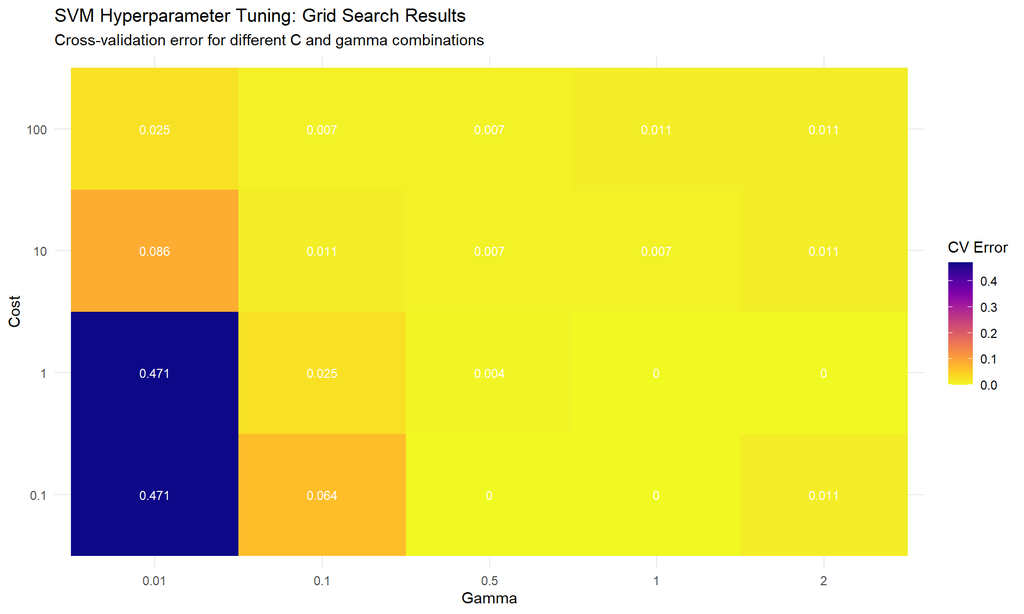

```r
# Extract performance data
perf_data <- tune_result$performances

# Heatmap of error rates
ggplot(perf_data, aes(x = factor(gamma), y = factor(cost), fill = error)) +
  geom_tile() +
  geom_text(aes(label = round(error, 3)), color = "white", size = 3) +
  scale_fill_viridis(option = "plasma", direction = -1) +
  labs(title = "SVM Hyperparameter Tuning: Grid Search Results",
       subtitle = "Cross-validation error for different C and gamma combinations",
       x = "Gamma", y = "Cost", fill = "CV Error") +
  theme_minimal()
```

Next we evaluate the best tuned model on the held-out test set.

```r
# Get the best model
best_svm <- tune_result$best.model

# Predictions on test set
svm_pred <- predict(best_svm, test_data)

# Confusion matrix
confusionMatrix(svm_pred, test_data$class)
```

```
## Confusion Matrix and Statistics
##
##           Reference
## Prediction  A  B
##          A 68  1
##          B  0 51
##
##                Accuracy : 0.9917
##                  95% CI : (0.9544, 0.9998)
##     No Information Rate : 0.5667
##     P-Value [Acc > NIR] : <2e-16
##
##                   Kappa : 0.983
##
##  Mcnemar's Test P-Value : 1
##
##             Sensitivity : 1.0000
##             Specificity : 0.9808
##          Pos Pred Value : 0.9855
##          Neg Pred Value : 1.0000
##              Prevalence : 0.5667
##          Detection Rate : 0.5667
##    Detection Prevalence : 0.5750
##       Balanced Accuracy : 0.9904
##
##        'Positive' Class : A
##
```

# 6 Real Case Study - Airline Delay Classification

In this section we move to a real operational dataset and predict whether a flight is delayed (`Delay`) or on time (`NoDelay`).

The Airline Delay data includes route, schedule, traffic, historical behavior, and weather variables. We turn `TotalDelay` into a binary target and keep all previous features as candidate predictors.

```r
# Load raw data
airline_raw <- read_csv("AirlineDelay.csv", show_col_types = FALSE)

# Build binary target and clean feature types
airline_data <- airline_raw %>%
  mutate(
    Delayed = factor(if_else(TotalDelay > 0, "Delay", "NoDelay"),
                     levels = c("Delay", "NoDelay")),
    across(c(Flight, Carrier, Month, DayOfWeek), as.factor),
    across(c(InsufficientHistory, OriginFog, OriginThunder, DestFog, DestThunder), as.factor)
  ) %>%
  select(-TotalDelay)

cat("Rows:", nrow(airline_data), " | Columns:", ncol(airline_data), "\n")
```

```
## Rows: 9381  | Columns: 23
```

Before fitting models, we inspect class balance, missing data, and a few basic delay patterns.

```r
class_balance <- airline_data %>%
  count(Delayed) %>%
  mutate(Share = scales::percent(n / sum(n)))

class_balance
```

```
## # A tibble: 2 × 3
##   Delayed     n Share
##   <fct>   <int> <chr>
## 1 Delay    4693 50.027%
## 2 NoDelay  4688 49.973%
```

```r
missing_summary <- airline_data %>%
  summarize(across(everything(), ~ sum(is.na(.)))) %>%
  pivot_longer(cols = everything(), names_to = "Variable", values_to = "Missing") %>%
  summarize(TotalMissing = sum(Missing), VariablesWithMissing = sum(Missing > 0))

missing_summary
```

```
## # A tibble: 1 × 2
##   TotalMissing VariablesWithMissing
##          <int>                <int>
## 1            0                    0
```

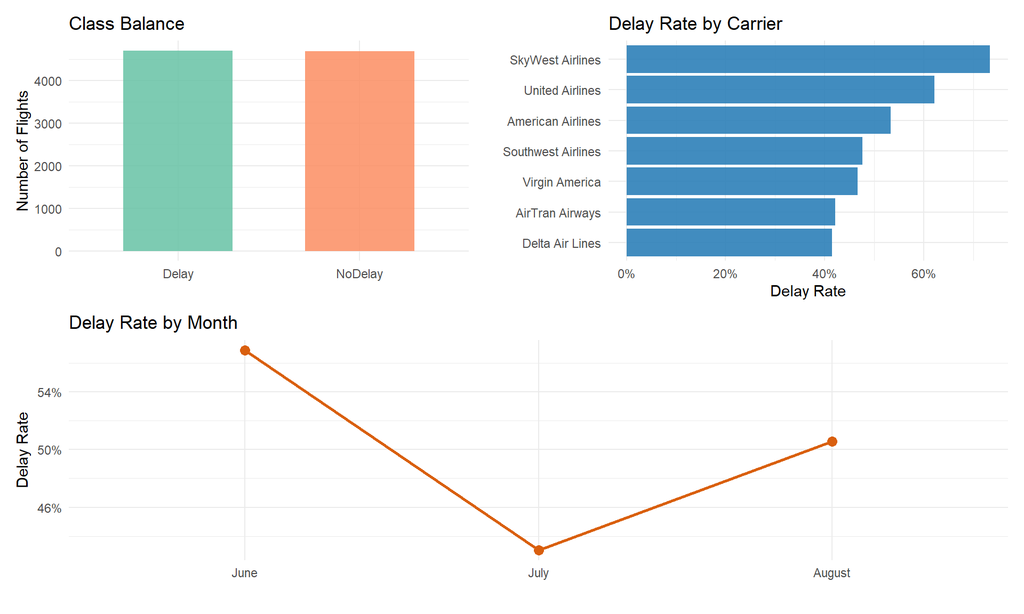

```r
p_class <- airline_data %>%
  count(Delayed) %>%
  ggplot(aes(x = Delayed, y = n, fill = Delayed)) +
  geom_col(width = 0.6, alpha = 0.85) +
  labs(title = "Class Balance", x = "", y = "Number of Flights") +
  scale_fill_brewer(palette = "Set2") +
  theme_minimal() +
  theme(legend.position = "none")

carrier_delay <- airline_raw %>%
  mutate(Delayed = TotalDelay > 0) %>%
  group_by(Carrier) %>%
  summarize(DelayRate = mean(Delayed), Flights = n(), .groups = "drop") %>%
  filter(Flights >= 200) %>%
  arrange(desc(DelayRate))

p_carrier <- ggplot(carrier_delay, aes(x = reorder(Carrier, DelayRate), y = DelayRate)) +
  geom_col(fill = "#2C7FB8", alpha = 0.9) +
  coord_flip() +
  scale_y_continuous(labels = scales::percent_format(accuracy = 1)) +
  labs(title = "Delay Rate by Carrier", x = "", y = "Delay Rate") +
  theme_minimal()

month_delay <- airline_raw %>%
  mutate(
    Delayed = TotalDelay > 0,
    Month = factor(Month, levels = c("June", "July", "August"))
  ) %>%
  group_by(Month) %>%
  summarize(DelayRate = mean(Delayed), .groups = "drop")

p_month <- ggplot(month_delay, aes(x = Month, y = DelayRate, group = 1)) +
  geom_line(color = "#D95F0E", linewidth = 1) +
  geom_point(color = "#D95F0E", size = 3) +
  scale_y_continuous(labels = scales::percent_format(accuracy = 1)) +
  labs(title = "Delay Rate by Month", x = "", y = "Delay Rate") +
  theme_minimal()

(p_class | p_carrier) / p_month
```

Now we create a stratified train/test split and preserve class proportions in both subsets.

```r
set.seed(123)
air_split <- createDataPartition(airline_data$Delayed, p = 0.8, list = FALSE)

air_train <- airline_data[air_split, ]
air_test <- airline_data[-air_split, ]

cat("Training size:", nrow(air_train), "\n")
```

```
## Training size: 7506
```

```r
cat("Test size:", nrow(air_test), "\n")
```

```
## Test size: 1875
```

```r
bind_rows(
  air_train %>% count(Delayed) %>% mutate(Set = "Train"),
  air_test %>% count(Delayed) %>% mutate(Set = "Test")
) %>%
  group_by(Set) %>%
  mutate(Share = round(n / sum(n), 3)) %>%
  ungroup()
```

```
## # A tibble: 4 × 4
##   Delayed     n Set   Share
##   <fct>   <int> <chr> <dbl>
## 1 Delay    3755 Train   0.5
## 2 NoDelay  3751 Train   0.5
## 3 Delay     938 Test    0.5
## 4 NoDelay   937 Test    0.5
```

```r
ctrl_air <- trainControl(
  method = "cv",
  number = 3,
  classProbs = TRUE,
  summaryFunction = twoClassSummary
)

set.seed(123)
air_logit <- train(
  Delayed ~ .,
  data = air_train,
  method = "glm",
  family = binomial(),
  trControl = ctrl_air,
  metric = "ROC",
  preProcess = c("center", "scale")
)

set.seed(123)
air_lda <- train(
  Delayed ~ .,
  data = air_train,
  method = "lda",
  trControl = ctrl_air,
  metric = "ROC",
  preProcess = c("center", "scale")
)

set.seed(123)
air_svm <- train(
  Delayed ~ .,
  data = air_train,
  method = "svmRadial",
  trControl = ctrl_air,
  metric = "ROC",
  preProcess = c("center", "scale"),
  tuneLength = 6
)

air_logit
```

```
## Generalized Linear Model
##
## 7506 samples
##   22 predictor
##    2 classes: 'Delay', 'NoDelay'
##
## Pre-processing: centered (38), scaled (38)
## Resampling: Cross-Validated (3 fold)
## Summary of sample sizes: 5003, 5005, 5004
## Resampling results:
##
##   ROC        Sens      Spec
##   0.7141031  0.645806  0.675019
```

```r
air_lda
```

```
## Linear Discriminant Analysis
##
## 7506 samples
##   22 predictor
##    2 classes: 'Delay', 'NoDelay'
##
## Pre-processing: centered (38), scaled (38)
## Resampling: Cross-Validated (3 fold)
## Summary of sample sizes: 5003, 5005, 5004
## Resampling results:
##
##   ROC        Sens       Spec
##   0.7136874  0.6423447  0.6782163
```

```r
air_svm
```

```
## Support Vector Machines with Radial Basis Function Kernel
##
## 7506 samples
##   22 predictor
##    2 classes: 'Delay', 'NoDelay'
##
## Pre-processing: centered (38), scaled (38)
## Resampling: Cross-Validated (3 fold)
## Summary of sample sizes: 5003, 5005, 5004
## Resampling results across tuning parameters:
##
##   C     ROC        Sens       Spec
##   0.25  0.7221552  0.6596554  0.6638218
##   0.50  0.7285267  0.6585884  0.6736891
##   1.00  0.7322261  0.6572574  0.6899507
##   2.00  0.7337099  0.6583232  0.6990163
##   4.00  0.7317329  0.6604548  0.6958152
##   8.00  0.7275887  0.6556608  0.6862192
##
## Tuning parameter 'sigma' was held constant at a value of 0.01631722
## ROC was used to select the optimal model using the largest value.
## The final values used for the model were sigma = 0.01631722 and C = 2.
```

This chunk evaluates test-set performance with accuracy, sensitivity, specificity, and AUC for each model.

```r
evaluate_binary_model <- function(model, test_data, model_name) {
  pred <- predict(model, test_data)
  prob_delay <- predict(model, test_data, type = "prob")[, "Delay"]
  cm <- confusionMatrix(pred, test_data$Delayed, positive = "Delay")
  roc_obj <- roc(
    response = test_data$Delayed,
    predictor = prob_delay,
    levels = c("NoDelay", "Delay"),
    quiet = TRUE
  )

  tibble(
    Model = model_name,
    Accuracy = as.numeric(cm$overall["Accuracy"]),
    Sensitivity = as.numeric(cm$byClass["Sensitivity"]),
    Specificity = as.numeric(cm$byClass["Specificity"]),
    AUC = as.numeric(auc(roc_obj))
  )
}

air_results <- bind_rows(
  evaluate_binary_model(air_logit, air_test, "Logistic Regression"),
  evaluate_binary_model(air_lda, air_test, "LDA"),
  evaluate_binary_model(air_svm, air_test, "SVM (Radial)")
) %>%
  arrange(desc(AUC))

air_results
```

```
## # A tibble: 3 × 5
##   Model               Accuracy Sensitivity Specificity   AUC
##   <chr>                  <dbl>       <dbl>       <dbl> <dbl>
## 1 SVM (Radial)           0.667       0.665       0.668 0.728
## 2 Logistic Regression    0.642       0.632       0.652 0.700
## 3 LDA                    0.639       0.628       0.651 0.700
```

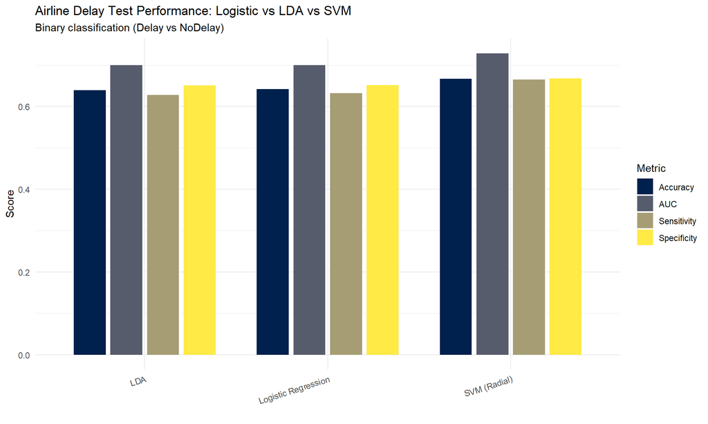

```r
air_results_long <- air_results %>%
  pivot_longer(cols = c(Accuracy, Sensitivity, Specificity, AUC),
               names_to = "Metric", values_to = "Value")

ggplot(air_results_long, aes(x = Model, y = Value, fill = Metric)) +
  geom_col(position = position_dodge(width = 0.8), width = 0.7) +
  labs(title = "Airline Delay Test Performance: Logistic vs LDA vs SVM",
       subtitle = "Binary classification (Delay vs NoDelay)",
       x = "", y = "Score") +
  scale_fill_viridis_d(option = "E") +
  theme_minimal() +
  theme(axis.text.x = element_text(angle = 18, hjust = 1))
```

We also compare ROC curves to visualize threshold trade-offs and ranking quality across models.

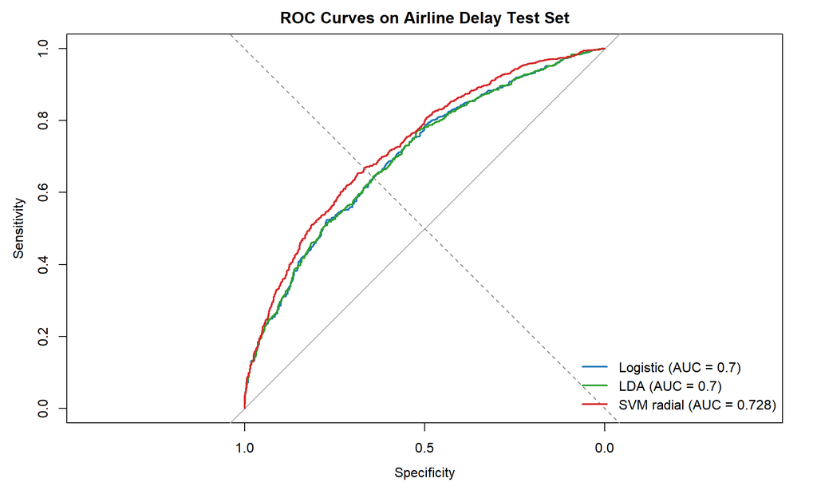

```r
prob_logit <- predict(air_logit, air_test, type = "prob")[, "Delay"]
prob_lda <- predict(air_lda, air_test, type = "prob")[, "Delay"]
prob_svm <- predict(air_svm, air_test, type = "prob")[, "Delay"]

roc_logit <- roc(air_test$Delayed, prob_logit, levels = c("NoDelay", "Delay"), quiet = TRUE)
roc_lda <- roc(air_test$Delayed, prob_lda, levels = c("NoDelay", "Delay"), quiet = TRUE)
roc_svm <- roc(air_test$Delayed, prob_svm, levels = c("NoDelay", "Delay"), quiet = TRUE)

plot(roc_logit, col = "#1F77B4", lwd = 2, main = "ROC Curves on Airline Delay Test Set")
lines(roc_lda, col = "#2CA02C", lwd = 2)
lines(roc_svm, col = "#D62728", lwd = 2)
abline(a = 0, b = 1, lty = 2, col = "gray50")

legend(
  "bottomright",
  legend = c(
    paste0("Logistic (AUC = ", round(auc(roc_logit), 3), ")"),
    paste0("LDA (AUC = ", round(auc(roc_lda), 3), ")"),
    paste0("SVM radial (AUC = ", round(auc(roc_svm), 3), ")")
  ),
  col = c("#1F77B4", "#2CA02C", "#D62728"),
  lwd = 2,
  bty = "n"
)
```

# 7 Multi-Class SVM

SVM is inherently a binary classifier, but can be extended to multi-class problems using:

- **One-vs-One**: Train k(k-1)/2 classifiers for k classes
- **One-vs-All**: Train k classifiers, each separating one class from all others

```r
# Use iris data (3 classes)
data(iris)

# Split
set.seed(123)
iris_idx <- createDataPartition(iris$Species, p = 0.7, list = FALSE)
iris_train <- iris[iris_idx, ]
iris_test <- iris[-iris_idx, ]

# Train multi-class SVM
svm_multi <- svm(Species ~ ., data = iris_train, kernel = "radial")

# The e1071 package uses OvO by default
summary(svm_multi)
```

```
##
## Call:
## svm(formula = Species ~ ., data = iris_train, kernel = "radial")
##
##
## Parameters:
##    SVM-Type:  C-classification
##  SVM-Kernel:  radial
##        cost:  1
##
## Number of Support Vectors:  44
##
##  ( 8 19 17 )
##
##
## Number of Classes:  3
##
## Levels:
##  setosa versicolor virginica
```

```r
# Predictions
multi_pred <- predict(svm_multi, iris_test)

# Confusion matrix
confusionMatrix(multi_pred, iris_test$Species)
```

```
## Confusion Matrix and Statistics
##
##             Reference
## Prediction   setosa versicolor virginica
##   setosa         15          0         0
##   versicolor      0         14         2
##   virginica       0          1        13
##
## Overall Statistics
##
##                Accuracy : 0.9333
##                  95% CI : (0.8173, 0.986)
##     No Information Rate : 0.3333
##     P-Value [Acc > NIR] : < 2.2e-16
##
##                   Kappa : 0.9
##
##  Mcnemar's Test P-Value : NA
##
## Statistics by Class:
##
##                      Class: setosa Class: versicolor Class: virginica
## Sensitivity                 1.0000            0.9333           0.8667
## Specificity                 1.0000            0.9333           0.9667
## Pos Pred Value              1.0000            0.8750           0.9286
## Neg Pred Value              1.0000            0.9655           0.9355
## Prevalence                  0.3333            0.3333           0.3333
## Detection Rate              0.3333            0.3111           0.2889
## Detection Prevalence        0.3333            0.3556           0.3111
## Balanced Accuracy           1.0000            0.9333           0.9167
```

Finally, we project the iris problem onto two features and visualize the learned multi-class regions.

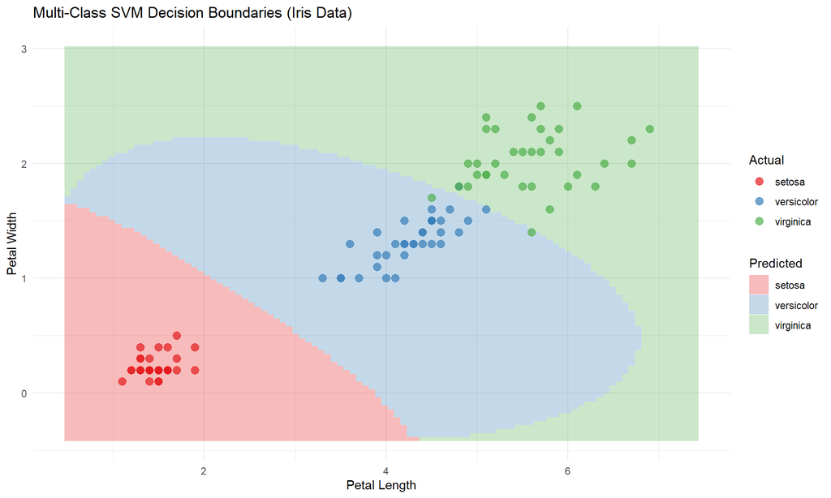

```r
# Use only 2 features for visualization
svm_2d <- svm(Species ~ Petal.Length + Petal.Width, data = iris_train, kernel = "radial")

# Create grid
pl_range <- seq(min(iris$Petal.Length) - 0.5, max(iris$Petal.Length) + 0.5, length = 100)
pw_range <- seq(min(iris$Petal.Width) - 0.5, max(iris$Petal.Width) + 0.5, length = 100)
grid_iris <- expand.grid(Petal.Length = pl_range, Petal.Width = pw_range)
grid_iris$pred <- predict(svm_2d, grid_iris)

# Plot
ggplot() +
  geom_tile(data = grid_iris, aes(x = Petal.Length, y = Petal.Width, fill = pred), alpha = 0.3) +
  geom_point(data = iris_train, aes(x = Petal.Length, y = Petal.Width, color = Species),
             size = 3, alpha = 0.7) +
  labs(title = "Multi-Class SVM Decision Boundaries (Iris Data)",
       x = "Petal Length", y = "Petal Width") +
  theme_minimal() +
  scale_fill_brewer(palette = "Set1", name = "Predicted") +
  scale_color_brewer(palette = "Set1", name = "Actual")
```